# Aderência dos deputados em votações de Meio Ambiente

### Resumo

Analisamos quais deputados federais mais/menos seguem as orientações de seus partidos e do governo nas votações nominais em plenário da Câmara. Usamos as votações que aconteceram em 2019.

### O que é aderência

Aderência é uma faceta da atuação dos Deputados Federais na câmara em votações. Um deputado é aderente ao partido quando segue as orientações de seu partido em votações nominais. De forma análoga, o deputado pode ser aderente ao governo se segue suas orientações.

Para cada votação de cada deputado, identificamos se ele seguiu a orientação do partido e do governo ou não. Em seguida, calculamos o grau de aderência como a proporção das votações em que ele seguiu a orientação do partido ou do governo. Quando o partido ou o governo liberou o deputado em uma votação, essa votação não é considerada.

Existe 1 proposição que possui votações em plenário cujo tema é classificado como **Meio Ambiente**. A **MPV 867/2018** que prorroga o prazo para adesão de produtores rurais ao Programa de Regularização Ambiental. Essa MPV teve 23 votações em plenário.

## Aderência ao Governo

### Quem tem menos aderência?

Abaixo apresentamos a lista dos 20 deputadas e deputados que menos seguiram a orientação do Governo para as votações relacionadas ao Meio Ambiente.

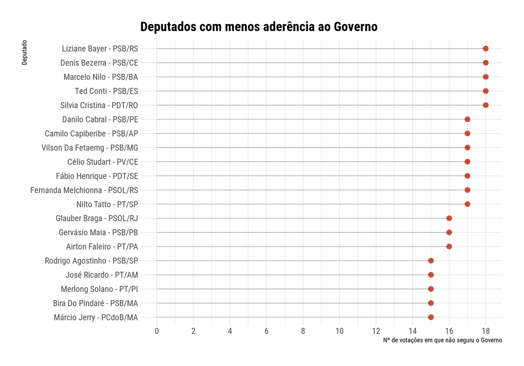

Todos estes deputados possuem uma aderência de 0% ao governo e estão ordenados pelo número de votações em que não seguiu a orientação do governo.

Existem outros 62 deputados que também possuem 0% de aderência ao governo. Você pode conferir a lista no fim deste relatório.

### Mais detalhes sobre quem não adere

Para saber mais detalhes sobre o comportamento destes deputados nas 23 votações nominais acompanhe o gráfico abaixo.

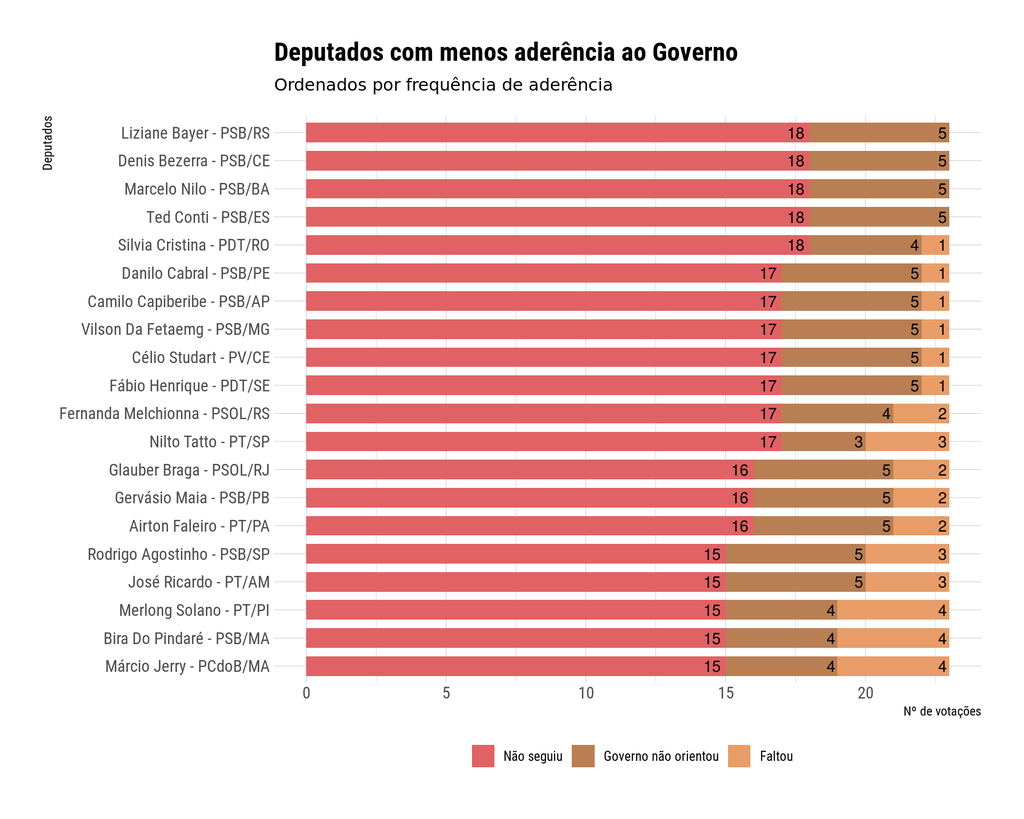

### Quem tem mais aderência?

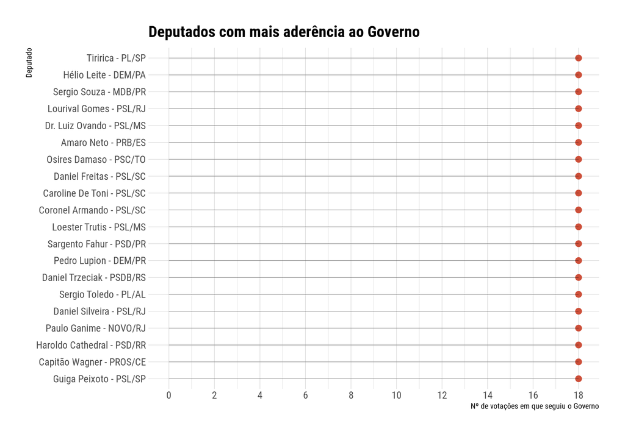

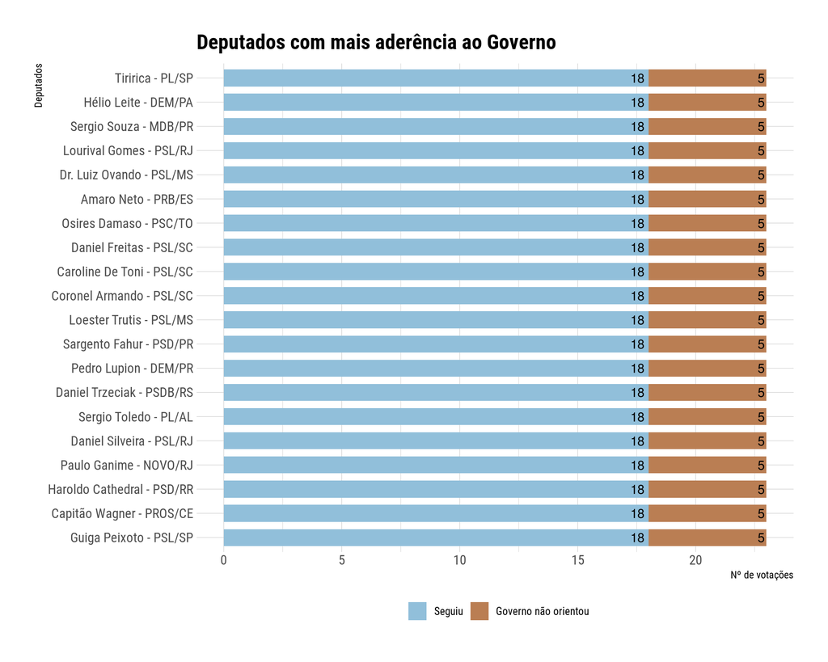

### Aderência por partido

Agora estamos interessados em analisar como os partidos e seus componentes seguem a orientação do Governo ou não para o tema de Meio Ambiente.

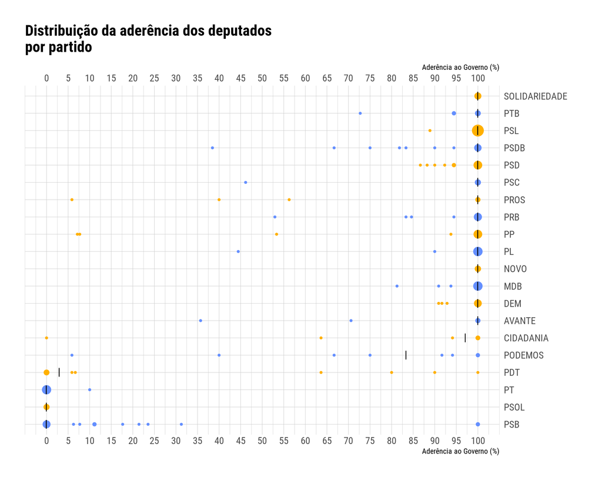

A marca “|” representa a mediana no gráfico. A mediana também é o critério de ordenação dos partidos. A maioria dos partidos aderem em 100% de mediana

Pela visualização é possível perceber que existem claramente partidos que divergem da orientação do governo quando consideramos a mediana das aderências de seus membros. Em outras palavras, deputados do PT, PSOL e PDT e PSB pouco ou nunca aderem a orientação do Governo para as votações de Meio Ambiente. No entanto, existem outliers para esse grupo, como alguns deputados do PDT que possuem aderência superior a 60% ao Governo e dois deputados doo PSB com aderência de 100% ao Governo (Átila Lira - PSB/PI e Rodrigo Coelho - PSB/SC).

### Por votação

Olhando de forma geral se os deputados seguiram ou não a orientação do Governo para as 23 votações de Meio Ambiente que aconteceram em 2019 podemos identificar que

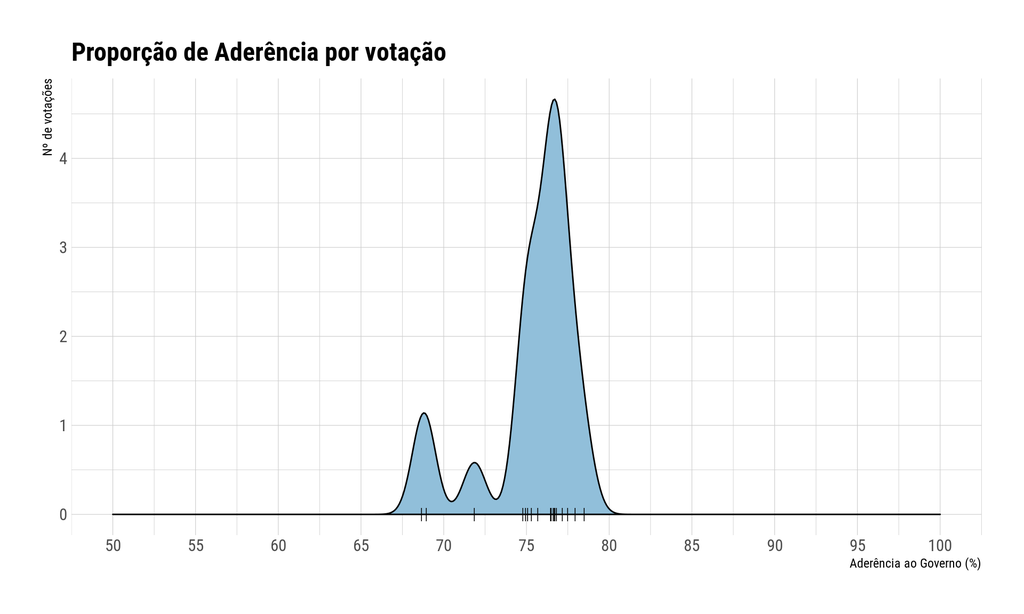

Todas as votações se concentram na faixa entre 60% e 80% de aderência ao Governo. Ou seja, o governo acaba tendo a maioria dos votos a seu favor. Foram removidas da visualização as votações nas quais o Governo não orientou.

Abaixo apresentamos uma tabela pesquisável com os dados de todos os deputados que participaram de votações no ano de 2019.

| id | Nome | Partido | Aderência | Seguiu | Não Seguiu | Faltou | Governo liberou |
| --- | --- | --- | --- | --- | --- | --- | --- |
| 132504 | Enio Verri - PT/PR | PT | 0 | 0 | 10 | 11 | 2 |
| 134812 | Edmilson Rodrigues - PSOL/PA | PSOL | 0 | 0 | 12 | 7 | 4 |
| 139285 | Lídice Da Mata - PSB/BA | PSB | 0 | 0 | 11 | 10 | 2 |
| 141335 | Beto Faro - PT/PA | PT | 0 | 0 | 11 | 9 | 3 |
| 141464 | José Airton Félix Cirilo - PT/CE | PT | 0 | 0 | 14 | 5 | 4 |
| 152605 | Glauber Braga - PSOL/RJ | PSOL | 0 | 0 | 16 | 2 | 5 |
| 160511 | Alessandro Molon - PSB/RJ | PSB | 0 | 0 | 13 | 7 | 3 |
| 160528 | Danilo Cabral - PSB/PE | PSB | 0 | 0 | 17 | 1 | 5 |
| 160538 | Bohn Gass - PT/RS | PT | 0 | 0 | 10 | 11 | 2 |
| 160556 | Padre João - PT/MG | PT | 0 | 0 | 13 | 6 | 4 |

[output cut: 357 more lines]